# [Phystech@DataScience](https://mipt-stats.gitlab.io/courses/ad_mipt.html)

## Задание 4а

**Правила:**

- Выполненную работу нужно отправить телеграм-боту `@miptstats_pds_bot`.
- Дедлайн **27 марта в 22:00**. После дедлайна работы не принимаются кроме случаев наличия уважительной причины.
- Прислать нужно ноутбук в формате `ipynb` и все фотографии, если пишете теоретическую часть от руки.
- Решения, размещенные на каких-либо интернет-ресурсах, не принимаются. Публикация решения может быть приравнена к предоставлении возможности списать.
- Для выполнения задания используйте этот ноутбук в качестве основы, ничего не удаляя из него.

*Замечания.* Теоретические решения можно оформить

- в $\LaTeX$-формате в ноутбуке;
- написать от руки и прикрепить к ноутбуку;
- написать от руки и выслать боту.

Во втором случае также **важно** "вшить" фото в ноутбук. Сделать это можно с помощью Edit -> Insert Image в Jupyter или с помощью кнопки "Вставить изображение" в Colab. Следите за размером итогового файла.

Фотографии принимаются только в хорошем качестве, **следите за освещением и почерком**. На фотографиях также указывайте номера задач.

```python
import numpy as np
import pandas as pd
import scipy.stats as sps

import matplotlib.pyplot as plt
import seaborn as sns
import plotly.subplots as sub
import plotly.graph_objects as go
import plotly as py

red = 'rgba(255,0,0,0.1)'
blue = 'rgba(0,0,255,0.1)'
green = 'rgba(0,255,0,0.1)'
```

# Теоретическая часть

### Задача 1 (3 балла).

В 1963 году на одном из самолетов модели Boeing 720 были проведены измерения времени между поломками системы кондиционирования (в часах):

`487, 18, 100, 7, 98, 5, 85, 91, 43, 230, 3, 130`

Данные хорошо описываются экспоненциальным распределением с параметром $\theta > 0$. Нахождение точечной и интервальной оценок $\theta$ имеет практическое применение.

Пусть

$X_1,\ldots,X_n$ — выборка из экспоненциального распределения с параметром $\theta$, т.е. $p_\theta(x) = \theta e^{-\theta x}I(x>0)$.

Найдите точный доверительный интервал для параметра $\theta$ уровня доверия $\alpha$ с помощью метода центральной функции.

Посчитайте реализацию доверительного интервала на предложенных данных, положив $\alpha = 0.95$.

*Замечание. Экспоненциальное распределение также хорошо описывает время между соседними появлениями частицы на детекторе.*

> **Решение:**

> Возьмём в качестве центральной статистики $g(\theta)=\sum{X_i}-n\theta$, которая распределена как $\Gamma(1,n)$. Тогда для поиска доверительного интервала уровня $\alpha$ используем квантили гамма-распределения $\gamma_{\frac{1+\alpha}{2}}$ и $\gamma_{\frac{1-\alpha}{2}}$. Отсюда получим, что $\gamma_{\frac{1-\alpha}{2}}\leq g \gamma_{\frac{1+\alpha}{2}}$ или $\overline{X}-\gamma_{\frac{1+\alpha}{2}}\leq\theta\leq\overline{X}-\gamma_{\frac{1-\alpha}{2}}$. Подставляя наши значения, получим $92.4\leq\theta\leq96.1$

### Задача 2 (5 баллов).

Постройте асимптотический доверительный интервал для $\theta$ уровня доверия $\alpha$.

а) $X_1,\ldots,X_n$ — координаты пересечении гамма-лучей с горизонтальной прямой, являющиеся выборкой из распределения Коши со сдвигом, т.е. $ p_{\theta}(x)=\frac 1{\pi(1+(x-\theta)^2)}. $

> **Решение**

> Как известно, выборочная медиана $\widehat{\mu}$ является АНО $\theta$ для распределения Коши. Используя ОШО найдём, что $\widehat{\theta_1}=\widehat{\mu}+\left(\sum\limits_{i=1}^n{\frac{X_i-\widehat{\mu}}{1+(X_i-\widehat{\mu})^2}}\right)/\left(\sum\limits_{i=1}^n{\frac{1-(X_i-\widehat{\mu})^2}{(1+(X_i-\widehat{\mu})^2)^2}}\right)$ является АНО $\theta$ с асимптотической дисперсией 2. Тогда асимптотическим доверительным интервалом будет $\left(\widehat{\theta_1}-\frac{\sqrt{2}\cdot z_{\frac{1+\alpha}{2}}}{\sqrt{n}},\widehat{\theta_1}+\frac{\sqrt{2}\cdot z_{\frac{1+\alpha}{2}}}{\sqrt{n}}\right)$

б) $X_1,\ldots,X_n$ — выборка из гамма-распределения с параметрами $(\theta,\beta)$, $\beta$ известно.

> **Решение**

> Как известно из предыдущего задания $\widehat{\theta}=\frac{\beta}{\overline{X}}$ является АНО для $\theta$ с асимптотической дисперсией $\frac{\widehat{\theta}^2}{\beta}$. Тогда асимтотическим доверительным интервалом будет $\left(\widehat{\theta}-\frac{\frac{\widehat{\theta}}{\sqrt{\beta}}\cdot z_{\frac{1+\alpha}{2}}}{\sqrt{n}},\widehat{\theta}+\frac{\frac{\widehat{\theta}}{\sqrt{\beta}}\cdot z_{\frac{1+\alpha}{2}}}{\sqrt{n}}\right)$

> Рассчёты для первой задачи

```python
a = np.array([487, 18, 100, 7, 98, 5, 85, 91, 43, 230, 3, 130])
print(a.mean() - sps.gamma(1, 12).ppf(1.95 / 2), a.mean() - sps.gamma(1, 12).ppf(0.05 / 2))
```

```
92.3944538792194 96.05801552534903
```

# Практическая часть

### Задача 3 (10 баллов).

В этой задаче нужно визуализировать доверительные интервалы.

Рассмотрим пример построения доверительного интервала для оценки $\theta$ для выборки из $\mathcal{N}(\theta, 1)$. Приведенный ниже код строит график зависимости оценки $\overline{X}$, а также границ доверительного интервала $\left(\overline{X} - \frac{2}{\sqrt{n}}, \overline{X} + \frac{2}{\sqrt{n}}\right)$ от размера выборки $n$. В примере рассматривается реализация выборки размера 200 из стандартного нормального распределения и построенные по всем начальным подвыборкам оценка и доверительный интервал.

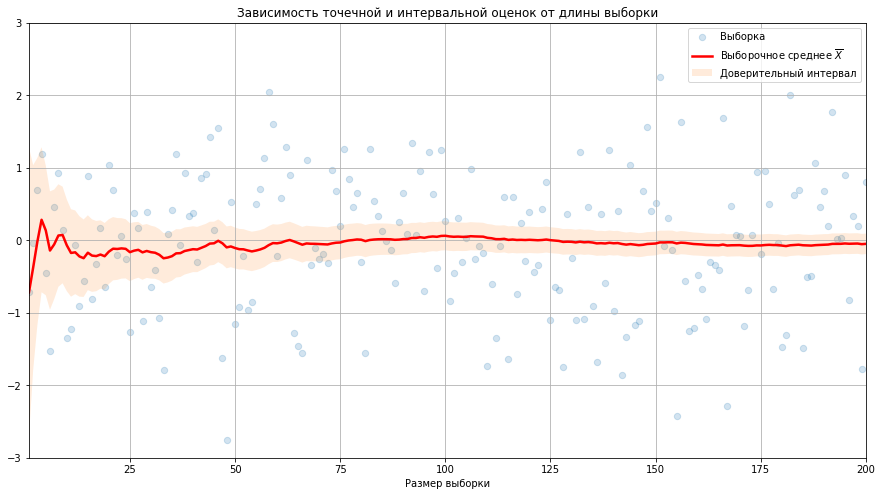

```python
sample = sps.norm.rvs(size=200)  # выборка

time = np.arange(1, 201)
means = sample.cumsum() / np.arange(1, 201)  # оценка

plt.figure(figsize=(15, 8))
plt.scatter(time, sample, alpha=0.2, s=40, label='Выборка')  # s - размер точек
plt.plot(time, means, color='red', linewidth=2.5, label='Выборочное среднее $\overline{X}$')  # linewidth - толщина линии

# заполняет пространство между двумя функциями
plt.fill_between(time, means + 2 / np.sqrt(time), means - 2 / np.sqrt(time), label = 'Доверительный интервал', alpha=0.15)

plt.legend()
plt.xlim((1, 200))  # размеры графика по горизонтальной оси (ставим None, если по стороне ограничений нет)
plt.ylim((-3, 3))  # размеры графика по вертикальной оси
plt.xlabel('Размер выборки')  # название горизонтальной оси (аналогично plt.ylabel)
plt.title('Зависимость точечной и интервальной оценок от длины выборки')  # имя графика
plt.grid()  # добавляем сетку
plt.show()
```

Чтобы не плодить код, напишите следующую функцию (см. ниже). Можете опираться на пример выше. При выборе стиля графика помните, что если изображаются лишь точки и линии, то лучше использовать серый фон, а если присутствуют закрашенные области, то предпочтительнее белый. Графики первого типа еще называют "легкими", а второго — "тяжелыми".

```python
def draw_confidence_interval(
    left, right, estimation=None, sample=None,
    ylim=(None, None), color_estimation='#FF3300', color_interval='#00CC66',
    color_sample='#0066FF', label_estimation='Оценка'
):
    """
    Рисует доверительный интервал и оценку в зависимости от размера выборки.

    :param left: левые границы интервалов (в зависимости от n)
    :param right: правые границы интервалов (в зависимости от n)
    :param estimation: оценки (в зависимости от n)
    :param sample: выборка
    :param ylim: ограничение вертикальной оси
    :param color_estimation: цвет оценки
    :param color_interval: цвет интервала
    :param color_sample: цвет выборки
    :param label_estimation: подпись для оценки

    Функция ничего не возвращает.
    """

    #поступил иначе
```

Рассмотрим выборку $X_1, ... X_{100}$ из стандартного распределения Коши и доверительные интервалы для следующих случаев

- точный доверительный интервал в параметрической модели $\mathcal{N}(\theta, 1)$ *— выведен на лекции 5, см. замечание ниже*;
- точный асимптотический доверительный интервал в параметрической модели распределения Коши со сдвигом, используя выборочную медиану в качестве асимптотически нормальной оценки;
- точный асимптотический доверительный интервал в параметрической модели распределения Коши со сдвигом, используя асимптотически эффективную оценку *, т.е имеющую наименьшую асимптотическую дисперсию. Вспомните лекцию 4 и прошлое ДЗ. Значение ее асимптотической дисперии можно взять с лекции без пояснений*.

Последние два интервала постройте с помощью метода построения асимптотических доверительных интервалов с лекции 5. Наверняка, какой-то из них у вас уже получился в теоретической части ДЗ.

*Замечание.*

Первый пример призван проиллюстрировать, что бывает, если используется неправильная модель. На практике вы никогда не знаете, из какого семейства распределений на самом деле получены данные.

Выпишите формулы для всех используемых интервалов.

**Ответ:**

> - $\left(\overline{X}-\frac{z_{(1+\alpha)/2}}{\sqrt{n}}, \overline{X}+\frac{z_{(1+\alpha)/2}}{\sqrt{n}}\right)$
> - $\left(\widehat{\mu}-\frac{\frac{\pi}{2}\cdot z_{\frac{1+\alpha}{2}}}{\sqrt{n}},\widehat{\mu}+\frac{\frac{\pi}{2}\cdot z_{\frac{1+\alpha}{2}}}{\sqrt{n}}\right)$
> - $\left(\widehat{\theta}-\frac{\sqrt{2}\cdot z_{\frac{1+\alpha}{2}}}{\sqrt{n}},\widehat{\theta}+\frac{\sqrt{2}\cdot z_{\frac{1+\alpha}{2}}}{\sqrt{n}}\right)$

Для каждой ситуации из перечисленных выше сгенерируйте выборку $X_1, ... X_{100}$ из стандартного распределения Коши и постройте график доверительных интервалов уровня доверия $0.95$, вычисленных для всех подвыборок вида $X_1, ... X_i$, $1 \le i \le 100$.

Постройте графики зависимости верхних и нижних границ интервала от размера выборки, используя написанную функцию. Нужно нанести на график точки выборки. Для вычисления квантилей у каждого распределения из `scipy.stats` используйте функцию `ppf`.

*Замечание.*

Выборку надо сгенерировать один раз. Дело в том, что на практике при недостаточном размере выборки разумнее дособрать выборку, чем заново проводить все измерения.

Изобразите интервалы *на одном* графике полупрозрачными цветами. Точки выборки нужно нанести на график.

```python
N = 100
a = 0.95
```

```python
sample = np.random.standard_cauchy(N)
X = np.arange(1, N + 1)
```

```python
estimatiomns = {'N(\\theta,1)': [sample.cumsum() / X,
                      sample.cumsum() / X - sps.norm.ppf((1 + a) / 2) / X ** 0.5,
                      sample.cumsum() / X + sps.norm.ppf((1 + a) / 2) / X ** 0.5, blue],
                '\widehat{\mu}': [np.array([np.median(sample[:n]) for n in X]),
                      np.array([np.median(sample[:n]) for n in X]) - np.pi / 2 * sps.norm.ppf((1 + a) / 2) / X ** 0.5,
                      np.array([np.median(sample[:n]) for n in X]) + np.pi / 2 * sps.norm.ppf((1 + a) / 2) / X ** 0.5, red],
                '\widehat{\\theta_1}': [(np.array([np.median(sample[:n]) for n in X]) +
                       np.array([np.array([(i - val) / (1 + (i - val) ** 2) for i in sample[:(num + 1)]]).sum() for num, val in enumerate(np.array([np.median(sample[:n]) for n in X]))]) /
                       np.array([np.array([(1 - (i - val) ** 2) / ((1 + (i - val) ** 2)) ** 2 for i in sample[:(num + 1)]]).sum() for num, val in enumerate(np.array([np.median(sample[:n]) for n in X]))])),
                      (np.array([np.median(sample[:n]) for n in X]) +
                       np.array([np.array([(i - val) / (1 + (i - val) ** 2) for i in sample[:(num + 1)]]).sum() for num, val in enumerate(np.array([np.median(sample[:n]) for n in X]))]) /
                       np.array([np.array([(1 - (i - val) ** 2) / ((1 + (i - val) ** 2)) ** 2 for i in sample[:(num + 1)]]).sum() for num, val in enumerate(np.array([np.median(sample[:n]) for n in X]))])) -
                       2 ** 0.5 * sps.norm.ppf((1 + a) / 2) / X ** 0.5,
                      (np.array([np.median(sample[:n]) for n in X]) +
                       np.array([np.array([(i - val) / (1 + (i - val) ** 2) for i in sample[:(num + 1)]]).sum() for num, val in enumerate(np.array([np.median(sample[:n]) for n in X]))]) /
                       np.array([np.array([(1 - (i - val) ** 2) / ((1 + (i - val) ** 2)) ** 2 for i in sample[:(num + 1)]]).sum() for num, val in enumerate(np.array([np.median(sample[:n]) for n in X]))])) +
                       2 ** 0.5 * sps.norm.ppf((1 + a) / 2) / X ** 0.5, green]}
```

```python
py.offline.init_notebook_mode()

fig = go.Figure()

#прорисовка графиков (досаточно компактно и без функции, по-моему)

fig.add_traces(go.Scatter(x=X, y=sample, mode='markers', marker=dict(color='orange'), opacity=0.5, name='Выборка'))

for i in estimatiomns:
    fig.add_traces(go.Scatter(x=X, y=estimatiomns[i][1], name='conf. int', marker=dict(color=estimatiomns[i][3][:13] + '1)'), line=dict(dash='dashdot'), legendgroup=i, showlegend=False))
    fig.add_traces(go.Scatter(x=X, y=estimatiomns[i][2], name='conf. int', marker=dict(color=estimatiomns[i][3][:13] + '1)'), line=dict(dash='dashdot'), legendgroup=i,
                   fill='tonexty', fillcolor=estimatiomns[i][3]))
    fig.add_traces(go.Scatter(x=X, y=estimatiomns[i][0], name=i, marker=dict(color=estimatiomns[i][3][:13] + '1)'), legendgroup=i))

#Настройка полотна

fig.update_layout(width=950, height=800,
                  plot_bgcolor='white',
                  margin=dict(r=130, l=50, t=60, b=50),
                  title='Доверительные интервалы оценок, при различных размерах выборки',
                  xaxis=dict(title='n'))

fig.update_xaxes(showgrid=True, gridwidth=1, gridcolor='black',
                 zeroline=True, zerolinewidth=2, zerolinecolor='black',
                 showline=True, linewidth=2, linecolor='black', mirror=True,
                 range=[1, N])
fig.update_yaxes(showgrid=True, gridwidth=1, gridcolor='black',
                 zeroline=True, zerolinewidth=2, zerolinecolor='black',
                 showline=True, linewidth=2, linecolor='black', mirror=True)

fig.show()
```

[interactive chart not shown]

Сравните полученные интервалы.

> **Вывод:** Для предположения о том, что наша выборка имеет нормальное распределение построенный графки демонстрирует неверность этой гипотезы – оценка никуда не стремится. Для выборочной медианы и одношаговой оценки результаты получились ожидаемыми - они обе стремятся к нулю, но у ОШО уже доверительныйы интервал, так как она обладает меньшей асимптотической дисперсией. Доверительный интервал у предположения о то, что распределение нормальное самый маленький. При просмотре график а с включённой выборкой, можновидеть, почему среднее плохо работает, а медиана хорошо: потому что одна большое значение сильно сбивает среднее, а медиана слабо такое чувствует.